# Report_Human_Genome_Annotation

Ramon Larrode - ID 0221356307

2023-05-18

# Human genes analysis

## 1. Setup a project repository

### 1.1. Library Instaling:

```r
# Required standard libraries

libs_01 <- c("tidyverse", "httr", "rvest", "valr", "forcats", "scales", "ggplot2", "Hmisc", "nortest", "modeest", "remotes")

# Checking installed standard libs
missing_libs <- libs_01[!sapply(libs_01, requireNamespace, quietly = TRUE)]

# Installing of missing libs
if (length(missing_libs) > 0) {
  install.packages(missing_libs)
  text_01 <- "Libraries just installed"
} else {
  text_01 <- "Libraries previously installed"
}
print(text_01)
```

```
## [1] "Libraries previously installed"
```

```r
# Checking and installation of required specialized libraries - BiocManager

if (!require("BiocManager", quietly = TRUE))
    install.packages("BiocManager")
```

```r
# Checking and installation of required specialized libraries - rtracklayer

if (!require("rtracklayer", quietly = TRUE))
    BiocManager::install("rtracklayer")
```

### 1.2. Library Activation:

```r
libraries <- c("tidyverse", "httr", "rvest", "valr", "forcats", "scales", "ggplot2", "Hmisc", "nortest", "modeest", "remotes", "rtracklayer")
inactive_libraries <- libraries[!sapply(libraries, function(x) is.element(x, search()))]
if (length(inactive_libraries) > 0) {
  lapply(inactive_libraries, require, character.only = TRUE)
  message <- "Libraries just activated"
} else {
  message <- "Libraries previously activated"
}
print(message)
```

```
## [1] "Libraries just activated"
```

> Parse [GENCODE](http://www.gencodegenes.org/) data to summarise some key features of the human genome.

The project will handle large data sets. Ensure that the code be run in the evaluation completely, i.e. that data is download, not stored in the repository.

## 2. Download data, set-up

- Go on the [latest human release](https://www.gencodegenes.org/human/) of **GENCODE** .
- Download the **Comprehensive gene annotation** as *Content* and **CHR** as *Regions*. Pick the **`GFF3`** format.
- Install the Bioconductor package [`rtracklayer`](http://bioconductor.org/packages/release/bioc/html/rtracklayer.html) to parse GFF files

if (!require(“BiocManager”, quietly = TRUE)) install.packages(“BiocManager”)

BiocManager::install(“rtracklayer”)

```r
url <- "https://ftp.ebi.ac.uk/pub/databases/gencode/Gencode_human/release_43/gencode.v43.annotation.gff3.gz"
fPath <- "gencode.v43.annotation.gff3.gz"

if (!file.exists(fPath)) {
  download.file(url, destfile = fPath)
} else {
  print("Data file already available")
}
```

```
## [1] "Data file already available"
```

## 3. Import the GFF file and converting to a ‘tibble’

- Import the GFF from GENCODE using the `import()` function from the package `rtracklayer`. Assign the result as `gencode`.

This steps requires some large memory, such as ~ 4 Gb. So your computer needs at least 8 Gb to perform this project. The object `gencode` below is 1.09 Gb alone.

`import()` returns an object of class GRanges. Converting to a `tibble` is more than encouraged.  
**Of note:** This operation takes about 2-3 minutes. You may want to save the object while testing your workflow. Moreover, the warning about `Warning in as.data.frame(mcols(x), ...): Arguments in '...' ignored` could be ignored.

```r
# Import data
if ("data" %in% ls()) {
  message("Data previously imported and available in the project.")
} else {
  data <- import(fPath, format = "gff")

  message("Data already imported and available in the project.")
}
```

```
## Data already imported and available in the project.
```

```r
# data <- import(fPath, format = "gff")
```

```r
if ("gencode" %in% ls()) {
  message("Tibble 'gencode' already exists in the project.")
} else {
  gencode <- as_tibble(data)
  message("Tibble 'gencode' created.")
}
```

```
## Tibble 'gencode' created.
```

```r
# gencode <- as_tibble(data)
head(gencode)
```

| seqnames | start | end | width | strand | source | type | score | phase | ID | gene_id | gene_type | gene_name | level | tag | Parent | transcript_id | transcript_type | transcript_name | transcript_support_level | havana_transcript | exon_number | exon_id | hgnc_id | havana_gene | ont | protein_id | ccdsid | artif_dupl |
| --- | --- | --- | --- | --- | --- | --- | --- | --- | --- | --- | --- | --- | --- | --- | --- | --- | --- | --- | --- | --- | --- | --- | --- | --- | --- | --- | --- | --- |
| chr1 | 11869 | 14409 | 2541 | + | HAVANA | gene | NA | NA | ENSG00000290825.1 | ENSG00000290825.1 | lncRNA | DDX11L2 | 2 |  |  | NA | NA | NA | NA | NA | NA | NA | NA | NA |  | NA | NA | NA |
| chr1 | 11869 | 14409 | 2541 | + | HAVANA | transcript | NA | NA | ENST00000456328.2 | ENSG00000290825.1 | lncRNA | DDX11L2 | 2 |  |  | ENST00000456328.2 | lncRNA | DDX11L2-202 | 1 | OTTHUMT00000362751.1 | NA | NA | NA | NA |  | NA | NA | NA |
| chr1 | 11869 | 12227 | 359 | + | HAVANA | exon | NA | NA | exon:ENST00000456328.2:1 | ENSG00000290825.1 | lncRNA | DDX11L2 | 2 |  |  | ENST00000456328.2 | lncRNA | DDX11L2-202 | 1 | OTTHUMT00000362751.1 | 1 | ENSE00002234944.1 | NA | NA |  | NA | NA | NA |
| chr1 | 12613 | 12721 | 109 | + | HAVANA | exon | NA | NA | exon:ENST00000456328.2:2 | ENSG00000290825.1 | lncRNA | DDX11L2 | 2 |  |  | ENST00000456328.2 | lncRNA | DDX11L2-202 | 1 | OTTHUMT00000362751.1 | 2 | ENSE00003582793.1 | NA | NA |  | NA | NA | NA |
| chr1 | 13221 | 14409 | 1189 | + | HAVANA | exon | NA | NA | exon:ENST00000456328.2:3 | ENSG00000290825.1 | lncRNA | DDX11L2 | 2 |  |  | ENST00000456328.2 | lncRNA | DDX11L2-202 | 1 | OTTHUMT00000362751.1 | 3 | ENSE00002312635.1 | NA | NA |  | NA | NA | NA |
| chr1 | 12010 | 13670 | 1661 | + | HAVANA | gene | NA | NA | ENSG00000223972.6 | ENSG00000223972.6 | transcribed_unprocessed_pseudogene | DDX11L1 | 2 |  |  | NA | NA | NA | NA | NA | NA | NA | HGNC:37102 | OTTHUMG00000000961.2 |  | NA | NA | NA |

| seqnames <fct> | start <int> | end <int> | width <int> | strand <fct> | source <fct> | type <fct> | score <dbl> | phase <int> |  |
| --- | --- | --- | --- | --- | --- | --- | --- | --- | --- |
| chr1 | 11869 | 14409 | 2541 | + | HAVANA | gene | NA | NA |  |
| chr1 | 11869 | 14409 | 2541 | + | HAVANA | transcript | NA | NA |  |
| chr1 | 11869 | 12227 | 359 | + | HAVANA | exon | NA | NA |  |
| chr1 | 12613 | 12721 | 109 | + | HAVANA | exon | NA | NA |  |
| chr1 | 13221 | 14409 | 1189 | + | HAVANA | exon | NA | NA |  |
| chr1 | 12010 | 13670 | 1661 | + | HAVANA | gene | NA | NA |  |

6 rows | 1-9 of 29 columns

Finally, `gencode` is the tibble used for the analysis

Now, it is going to be extracted a random sample from ‘gencode’ to simplify code creation:

```r
gencode_s <- gencode[sample(nrow(gencode), size = 5000),]
head(gencode_s)
```

| seqnames | start | end | width | strand | source | type | score | phase | ID | gene_id | gene_type | gene_name | level | tag | Parent | transcript_id | transcript_type | transcript_name | transcript_support_level | havana_transcript | exon_number | exon_id | hgnc_id | havana_gene | ont | protein_id | ccdsid | artif_dupl |
| --- | --- | --- | --- | --- | --- | --- | --- | --- | --- | --- | --- | --- | --- | --- | --- | --- | --- | --- | --- | --- | --- | --- | --- | --- | --- | --- | --- | --- |
| chr8 | 119806283 | 119806401 | 119 | - | HAVANA | CDS | NA | 1 | CDS:ENST00000690144.1 | ENSG00000064313.13 | protein_coding | TAF2 | 2 |  |  | ENST00000690144.1 | protein_coding | TAF2-232 | NA | NA | 4 | ENSE00003676424.1 | HGNC:11536 | OTTHUMG00000165009.5 |  | ENSP00000510548.1 | NA | NA |
| chr4 | 48831227 | 48831433 | 207 | + | HAVANA | five_prime_UTR | NA | NA | UTR5:ENST00000507210.5 | ENSG00000109180.15 | protein_coding | OCIAD1 | 2 |  |  | ENST00000507210.5 | protein_coding | OCIAD1-211 | 3 | OTTHUMT00000361865.3 | 2 | ENSE00002087329.1 | HGNC:16074 | OTTHUMG00000102095.19 |  | ENSP00000420917.1 | NA | NA |
| chr8 | 108228267 | 108228391 | 125 | - | HAVANA | exon | NA | NA | exon:ENST00000678334.1:10 | ENSG00000104408.11 | protein_coding | EIF3E | 2 |  |  | ENST00000678334.1 | protein_coding | EIF3E-248 | NA | NA | 10 | ENSE00003681490.1 | HGNC:3277 | OTTHUMG00000164858.7 |  | ENSP00000503856.1 | NA | NA |
| chr6 | 43012470 | 43012621 | 152 | - | HAVANA | CDS | NA | 2 | CDS:ENST00000244711.4 | ENSG00000124733.5 | protein_coding | MEA1 | 2 |  |  | ENST00000244711.4 | protein_coding | MEA1-201 | 1 | OTTHUMT00000040574.4 | 4 | ENSE00003815401.1 | HGNC:6986 | OTTHUMG00000014717.4 |  | ENSP00000244711.3 | CCDS4879.1 | NA |
| chr5 | 175961273 | 175961434 | 162 | - | ENSEMBL | exon | NA | NA | exon:ENST00000628318.2:3 | ENSG00000051596.10 | protein_coding | THOC3 | 3 |  |  | ENST00000628318.2 | protein_coding | THOC3-212 | 5 | NA | 3 | ENSE00003545316.1 | HGNC:19072 | OTTHUMG00000130658.2 |  | ENSP00000487428.1 | NA | NA |
| chr4 | 152264150 | 152264445 | 296 | - | ENSEMBL | exon | NA | NA | exon:ENST00000476053.2:1 | ENSG00000244544.2 | misc_RNA | RN7SL446P | 3 |  |  | ENST00000476053.2 | misc_RNA | RN7SL446P-201 | NA | NA | 1 | ENSE00001998997.2 | HGNC:46462 | NA |  | NA | NA | NA |

| seqnames <fct> | start <int> | end <int> | width <int> | strand <fct> | source <fct> | type <fct> | score <dbl> | phase <int> |  |
| --- | --- | --- | --- | --- | --- | --- | --- | --- | --- |
| chr8 | 119806283 | 119806401 | 119 | - | HAVANA | CDS | NA | 1 |  |
| chr4 | 48831227 | 48831433 | 207 | + | HAVANA | five_prime_UTR | NA | NA |  |
| chr8 | 108228267 | 108228391 | 125 | - | HAVANA | exon | NA | NA |  |
| chr6 | 43012470 | 43012621 | 152 | - | HAVANA | CDS | NA | 2 |  |
| chr5 | 175961273 | 175961434 | 162 | - | ENSEMBL | exon | NA | NA |  |
| chr4 | 152264150 | 152264445 | 296 | - | ENSEMBL | exon | NA | NA |  |

6 rows | 1-9 of 29 columns

## 4. Explore the human genome

### 4.1. What are the dimensions of this table?

```r
dim(gencode)
```

```
## [1] 3422750      29
```

### 4.2. There are too many lines for the number of genes we expect for the human genome (*i.e* ~ 20,000 genes). Look at the column `type`. What kind of data is this column?

```r
type(gencode[['type']])
```

[output not shown]

### 4.3. Display the levels of `type`

```r
levels(gencode[['type']])
```

```
## [1] "gene"
## [2] "transcript"
## [3] "exon"
## [4] "CDS"
## [5] "start_codon"
## [6] "stop_codon"
## [7] "five_prime_UTR"
## [8] "three_prime_UTR"
## [9] "stop_codon_redefined_as_selenocysteine"
```

Plot the count of each level from the `type` column.

Even if counting can be done manually with `dplyr`, try to be lazy and let `ggplot2` doing the job

- sorting the x-axis elements based on the count greatly help the reader to appreciate numbers. `forcats::infreq()` is your friend
- flipping coordinates help to read the x-axis labels. You can map the `y` aesthetic to `type` in ggplot2 v3.3.0.
- report the counts inside the bars to highlight them. Use `stat = "count"` in `geom_text()`. Using a fixed coordinate is also fine.
- a lighter theme like `theme_classic()` is usually better
- title and subtitle in the `labs()` give some context
- large numbers are usually easier to read with thousand comma separators. `scales::comma()` does it for you

### 4.4. Plot Distribution of Levels in Column `type`:

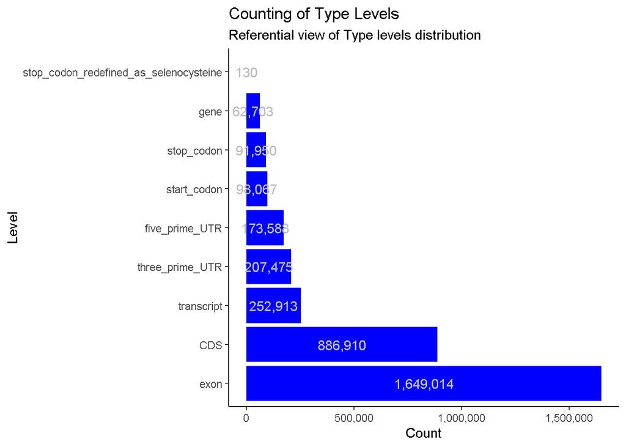

```r
# gencode gencode_s

plot_00 <- gencode |>
  mutate(type = fct_infreq(type)) |>
  ggplot(aes(x = type)) +
  geom_bar(fill = "Blue") +
  scale_y_continuous(labels = comma_format()) +
  geom_text(aes(label = scales::comma(after_stat(count))), stat = "count",
    position = position_stack(vjust = 0.5), color = "Grey") +
  coord_flip() +
  labs(x = "Level", y = "Count") +
  theme_classic() +
  ggtitle(label = "Counting of Type Levels",
    subtitle = "Referential view of Type levels distribution")
plot_00
```

### 4.5. From the previous plot, how many **gene** entries do you have?

From the previous plot, there are 62,703 **gene** entries in the dataset

### 4.6. Plot the distribution of the number of transcripts per gene, highlight the mean and median

The best columns for transcripts and genes are `transcripts_id` and `gene_id`. By distribution, we expect the density or binned histogram of the univariate number of transcript per gene. Depending on the distribution shape, log-transforming the counts is an option

To do this, it is needed first an intermediary table with not duplicated combinations `gene_id` - `transcript_id` (based on the sample data)

```r
gene_transc <- count(gencode_s, gene_id, transcript_id)
```

Now,it makes sense counting `gene_id`s

```r
gene_00 <- count(gene_transc, gene_id)
```

Finally the plot:

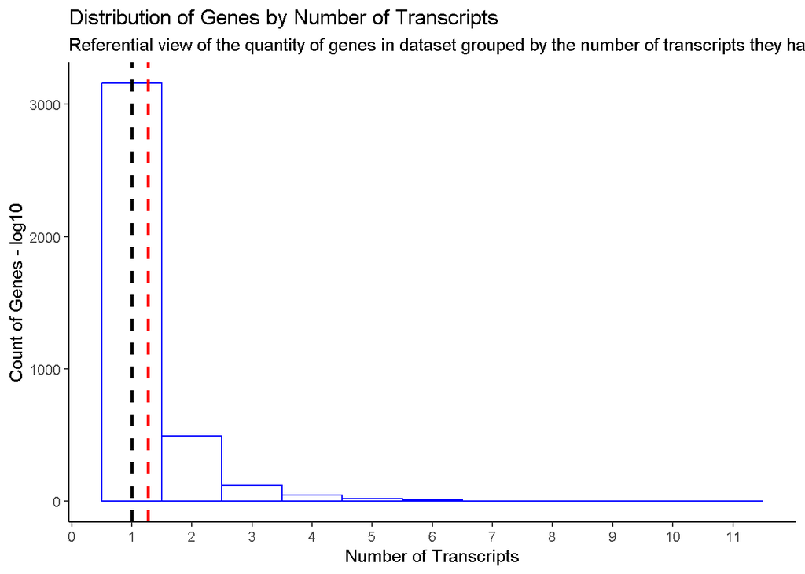

```r
plot02 <- gene_00 |>
    ggplot(aes(x = n)) +
    geom_histogram(fill = "White", colour = "Blue", binwidth = 1) +
    geom_vline(aes(xintercept=mean(n)),
      color = "Red",
      linetype = "dashed",
      linewidth = 1) +
    geom_vline(aes(xintercept=median(n)),
      color = "Black",
      linetype = "dashed",
      linewidth = 1) +
    scale_x_continuous(breaks=seq(0, max(gene_00$n), by=1)) +
    labs(x = "Number of Transcripts", y = "Count of Genes - log10") +
    theme_classic() +
    ggtitle(label = "Distribution of Genes by Number of Transcripts",
      subtitle = "Referential view of the quantity of genes in dataset grouped by the number of transcripts they have")
plot02
```

### 4.7. How many transcripts per gene do you observe using either the mean or the median in linear scale?

It seems like the average number of transcript per gene is 1 Transcript, and, at least 50% of the genes have only one Transcript

### 4.8. How do you explain the discrepancy between mean or median?

Discrepancy among mean and median could be caused by the distribution asymmetry of feature `Number of Transcript per gene`

## 5. Focus on genes

Now, let’s look at genes only.

### 5.1. Filter the `gencode` to restrict rows where type is **gene**, save as `genes`

```r
genes_00 <- filter(gencode, type == "gene")
```

### 5.2. Plot the counts of `gene_type` for `genes` in the same way you did the `type`. Sorting the counts.

You can restrict to counts > 500 to avoid showing all the smaller categories

```r
top500 <- filter(fct_count(genes_00$gene_type, sort = TRUE, prop = FALSE), n > 500)
```

```r
top500$f <- reorder(top500$f, top500$n)
```

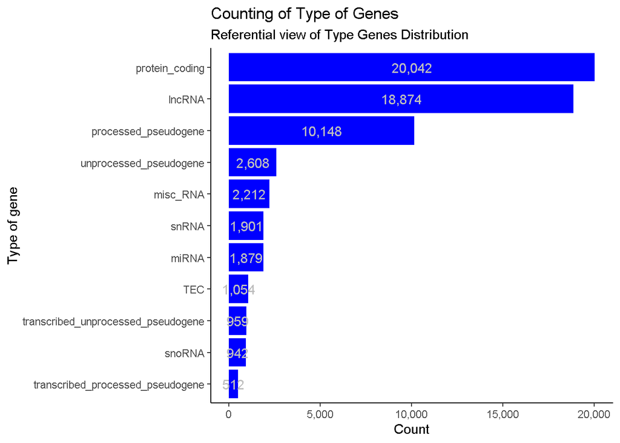

```r
plot05 <- ggplot(top500, aes(f, n)) +
  geom_col(fill = "Blue") +
  scale_y_continuous(labels = comma_format()) +
  geom_text(aes(label = scales::comma(n)), stat = "identity",
    position = position_stack(vjust = 0.5), color = "Grey") +
  coord_flip() +
  labs(x = "Type of gene", y = "Count") +
  theme_classic() +
  ggtitle(label = "Counting of Type of Genes",
    subtitle = "Referential view of Type Genes Distribution")
plot05
```

We can observe quite many unique `gene_type`, even restriction to the ones that are present > 500 times.

### 5.3. Collapse the levels of `gene_type` to create 4 meta-categories:

```
+ protein_coding as **prot_coding**
+ pseudogene as **pseudo**
+ **RNA**
+ lump the rest as **rest**
```

```r
genes_00 <- mutate(genes_00, meta_categories = fct_other(
  fct_collapse(genes_00$gene_type,
    prot_coding = "protein_coding",
    pseudo = c("processed_pseudogene",
      "unprocessed_pseudogene",
      "transcribed_unprocessed_pseudogene",
      "transcribed_processed_pseudogene"),
    RNA = c("lncRNA",
      "misc_RNA",
      "snRNA",
      "miRNA",
      "snoRNA")
  ), keep = c("prot_coding", "pseudo", "RNA"), other_level = "rest"))
```

```r
genes_01 <- fct_count(genes_00$meta_categories, sort = TRUE, prop = FALSE)
genes_01
```

| f | n |
| --- | --- |
| RNA | 25808 |
| prot_coding | 20042 |
| pseudo | 14227 |
| rest | 2626 |

| f <fct> | n <int> |  |  |  |
| --- | --- | --- | --- | --- |
| RNA | 25808 |  |  |  |
| prot_coding | 20042 |  |  |  |
| pseudo | 14227 |  |  |  |
| rest | 2626 |  |  |  |

4 rows

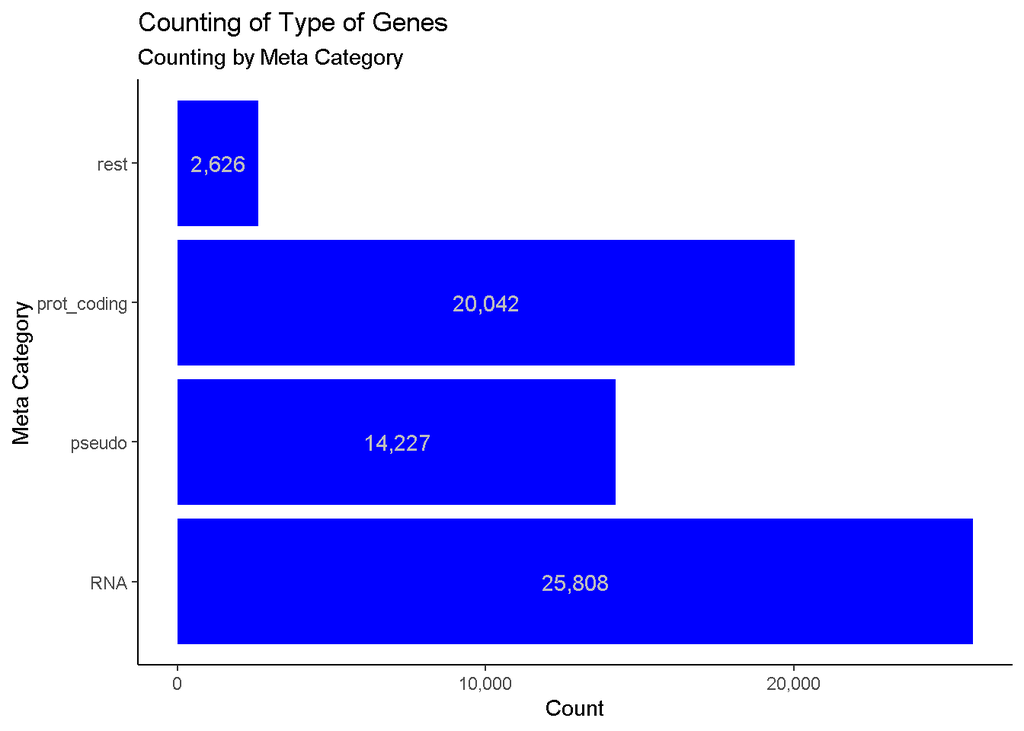

```r
plot_MetaC <- ggplot(genes_01, aes(f, n)) +
  geom_col(fill = "Blue") +
  scale_y_continuous(labels = comma_format()) +
  geom_text(aes(label = scales::comma(n)), stat = "identity",
    position = position_stack(vjust = 0.5), color = "Grey") +
  coord_flip() +
  labs(x = "Meta Category", y = "Count") +
  theme_classic() +
  ggtitle(label = "Counting of Type of Genes",
    subtitle = "Counting by Meta Category")
plot_MetaC
```

## 6. Genes per chromosome

Are the genes uniformly distributed across the genome? To address this question, we want to count the number of genes per chromosome and normalizing by the chromosome length.

You can use this [file from USCS](http://hgdownload-test.cse.ucsc.edu/goldenPath/hg38/bigZips/hg38.chrom.sizes) to get the chromosome sizes.

### 6.0. Data Engineering:

6.0.1. Getting the Chromosome Sizes Data.

```r
url1 = 'https://hgdownload-test.gi.ucsc.edu/goldenPath/hg38/bigZips/hg38.chrom.sizes'
```

```r
chSize_00 <- as_tibble(read.table(url1, header = FALSE, sep = "\t"))
```

```r
chr_01 <- fct_count(genes_00$seqnames, sort = FALSE, prop = FALSE)
```

```r
chrGMeta <- genes_00 |>
  group_by(meta_categories) |>
  count(seqnames)
```

6.0.2. Merging Datas

```r
chSize_01 <- left_join(chrGMeta, chSize_00, by = c("seqnames" = "V1"))
```

6.0.3. Transforming Features

```r
chSize_01 <- mutate(chSize_01, dGen_norm = 1000000*(n/V2))
```

```r
chr_01 <- fct_count(genes_00$seqnames, sort = FALSE, prop = FALSE)
```

```r
chr_02 <- left_join(chr_01, chSize_00, by = c("f" = "V1"))
```

```r
chr_02 <- mutate(chr_02, dGen_norm = 1000000*(n/V2))
```

### 6.1. Plot the gene density per chromosome and facet per the 4 meta categories

6.1.1. Agreggated Plot:

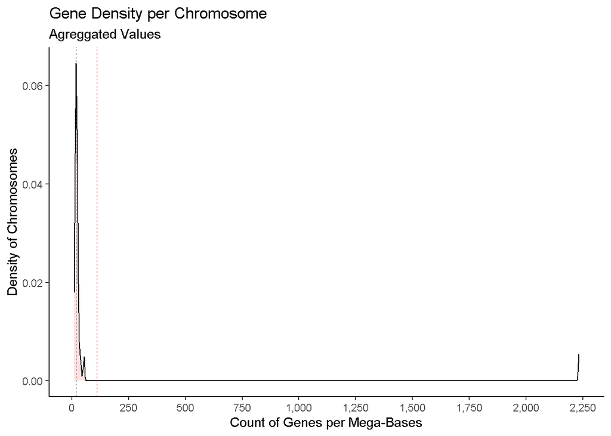

```r
plot06 <- ggplot(data = chr_02) +
  aes(x = dGen_norm) +
  geom_density(alpha = .2, fill = "#FF6666") +
  geom_vline(aes(xintercept=mean(dGen_norm)),
      color = "Red",
      linetype = "dashed",
      linewidth = .2) +
  geom_vline(aes(xintercept=median(dGen_norm)),
      color = "Black",
      linetype = "dashed",
      linewidth = .2) +
  scale_x_continuous(breaks=seq(0, max(chr_02$dGen_norm) + 500, by=250), labels = comma_format()) +
  theme_classic() +
  labs(title = "Gene Density per Chromosome",
    subtitle = "Agreggated Values",
    x = "Count of Genes per Mega-Bases",
    y = "Density of Chromosomes")

plot06
```

6.1.2. Facet plots per meta categories:

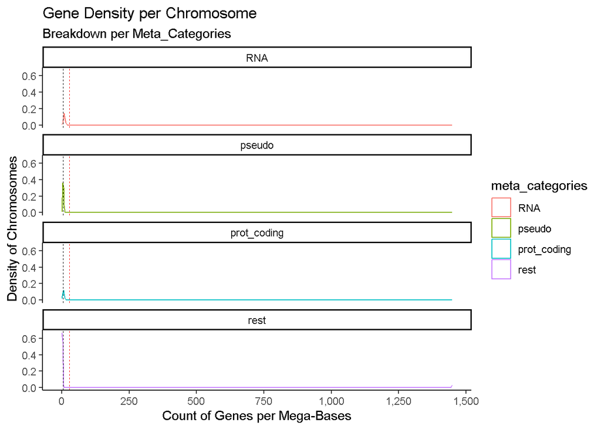

```r
plot_Facet <- ggplot(data = chSize_01) +
  aes(x = dGen_norm, color = meta_categories) +
  geom_density(alpha = .2) +
  geom_vline(aes(xintercept=mean(dGen_norm)),
      color = "Red",
      linetype = "dashed",
      linewidth = .2) +
  geom_vline(aes(xintercept=median(dGen_norm)),
      color = "Black",
      linetype = "dashed",
      linewidth = .2) +
  scale_x_continuous(breaks=seq(0, max(chSize_01$dGen_norm) + 500, by=250), labels = comma_format()) +
  theme_classic() +
  labs(title = "Gene Density per Chromosome",
    subtitle = "Breakdown per Meta_Categories",
    x = "Count of Genes per Mega-Bases",
    y = "Density of Chromosomes") +
  facet_wrap(meta_categories ~ ., ncol = 1, nrow = 4)

plot_Facet
```

### 6.2. Leaving out the **pseudogene** and **other** categories, what is striking in the results? What is so special with the MT?

6.2.1. Re-plot filtering out the mitochondria and keeping only **prot_coding** and **RNA**

```r
chSize_02 <- filter(chSize_01, meta_categories %in% c("RNA", "prot_coding"), seqnames != "chrM")
```

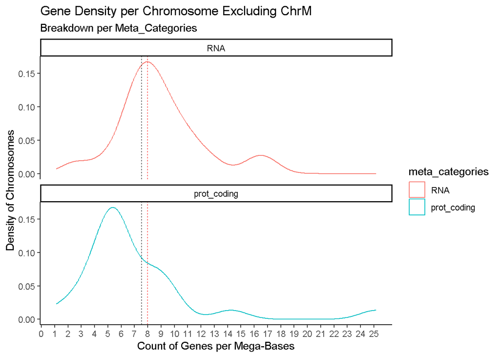

```r
plot_Facet_02 <- ggplot(data = chSize_02) +
  aes(x = dGen_norm, color = meta_categories) +
  geom_density(alpha = .2) +
  geom_vline(aes(xintercept=mean(chSize_02$dGen_norm)),
      color = "Red",
      linetype = "dashed",
      linewidth = .2) +
  geom_vline(aes(xintercept=median(chSize_02$dGen_norm)),
      color = "Black",
      linetype = "dashed",
      linewidth = .2) +
  scale_x_continuous(breaks=seq(0, max(chSize_02$dGen_norm)), labels = comma_format()) +
  theme_classic() +
  labs(title = "Gene Density per Chromosome Excluding ChrM",
    subtitle = "Breakdown per Meta_Categories",
    x = "Count of Genes per Mega-Bases",
    y = "Density of Chromosomes") +
  facet_wrap(meta_categories ~ ., ncol = 1, nrow = 2)

plot_Facet_02
```

6.2.2. What is the chromosome with the highest gene density?

```r
chr_Highest <- slice_max(chSize_02, dGen_norm)
chr_Highest
```

| meta_categories | seqnames | n | V2 | dGen_norm |
| --- | --- | --- | --- | --- |
| RNA | chr19 | 1001 | 58617616 | 17.07678 |
| prot_coding | chr19 | 1476 | 58617616 | 25.18014 |

| meta_categories <fct> | seqnames <chr> | n <int> | V2 <int> | dGen_norm <dbl> |
| --- | --- | --- | --- | --- |
| RNA | chr19 | 1001 | 58617616 | 17.07678 |
| prot_coding | chr19 | 1476 | 58617616 | 25.18014 |

2 rows

For Meta_Categories, “RNA” and “prot_coding”, the chromosome with the highest gene density is chr19 (after exclusion of chrM)

Breakdown by Meta_Category:

```r
chr_H_MetaC <- slice_max(chSize_01, dGen_norm)
chr_H_MetaC
```

| meta_categories | seqnames | n | V2 | dGen_norm |
| --- | --- | --- | --- | --- |
| RNA | chr19 | 1001 | 58617616 | 17.076778 |
| pseudo | chr19 | 503 | 58617616 | 8.581038 |
| prot_coding | chrM | 13 | 16569 | 784.597743 |
| rest | chrM | 24 | 16569 | 1448.488141 |

| meta_categories <fct> | seqnames <chr> | n <int> | V2 <int> | dGen_norm <dbl> |
| --- | --- | --- | --- | --- |
| RNA | chr19 | 1001 | 58617616 | 17.076778 |
| pseudo | chr19 | 503 | 58617616 | 8.581038 |
| prot_coding | chrM | 13 | 16569 | 784.597743 |
| rest | chrM | 24 | 16569 | 1448.488141 |

4 rows

If all Meta_Categories are compared, and chrM is not excluded, then, the chromosomes with the highest gene density are chr19 (“RNA”, “pseudo”) and chrM (prot_coding”, “rest”)

## 7. Gene sizes

How the gene sizes distribution look like? Here we are several questions, we are need to split sequentially. Also, we keep the 4 meta-categories previously obtained since they represent different kind of genes.

- plot the distribution of **gene** sizes using a density geometry filled by meta-category. The column `width` is directly giving you the length in base pairs.
- some genes have an extreme lengths, log-transformation must be evaluated.
- to keep the axis info in linear scale, you can use the function `annotation_logticks()`
- densities have by default no transparency, you should play with the `alpha` parameter

```r
geneSize_00 <- select(genes_00, gene_id, gene_name, meta_categories, width)
```

```r
geneSize_00 <- mutate(geneSize_00, logSize = log10(width))
# describe(geneSize_00)
```

### 7.1. Create Data Sample:

```r
# gencode_s <- gencode[sample(nrow(gencode), size = 5000),]
geneSize_S <- slice_sample(geneSize_00, n = 5000, replace = TRUE)
```

### 7.2. Plot:

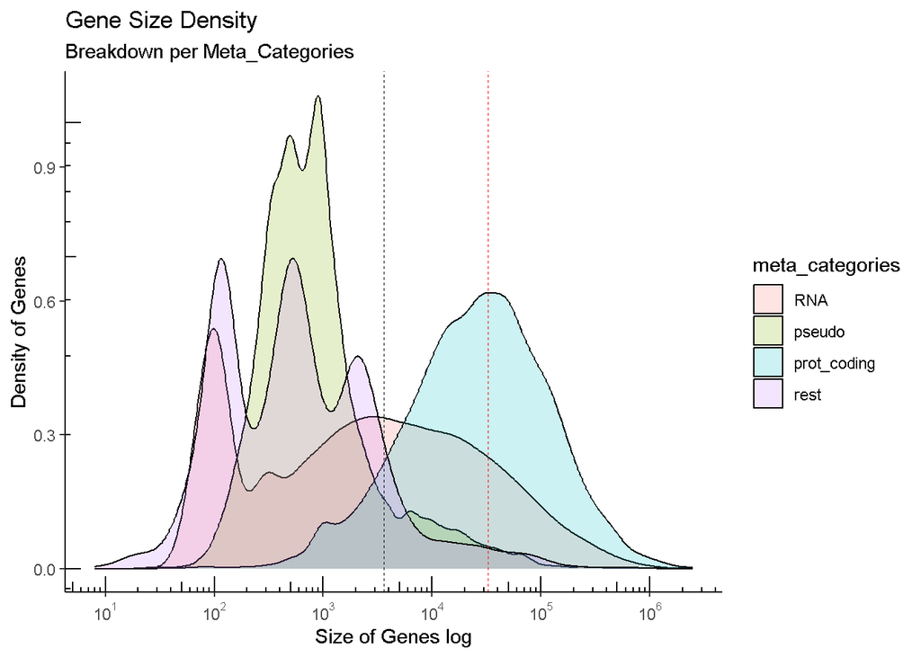

```r
plot_Filled_03 <- ggplot(data = geneSize_00) +
  aes(x = width, fill = meta_categories) +
  geom_density(alpha = .2) +
  geom_vline(aes(xintercept=mean(width)),
      color = "Red",
      linetype = "dashed",
      linewidth = .2) +
  geom_vline(aes(xintercept=median(width)),
      color = "Black",
      linetype = "dashed",
      linewidth = .2) +
  scale_x_log10(
    breaks = scales::trans_breaks("log10", function(x) 10^x),
    labels = scales::trans_format("log10", scales::math_format(10^.x))
  ) +
  annotation_logticks()+
  theme_classic() +
  labs(title = "Gene Size Density",
    subtitle = "Breakdown per Meta_Categories",
    x = "Size of Genes log",
    y = "Density of Genes")

plot_Filled_03
```

### 7.3. Which meta-category has the most normal distribution after log-transformation? And the largest average size?

Average Comparison:

```r
geneGMeta <- geneSize_00 |>
  group_by(meta_categories) |>
  summarise(avgSize = mean(width))
geneGMeta
```

| meta_categories | avgSize |
| --- | --- |
| RNA | 23089.625 |
| pseudo | 3129.933 |
| prot_coding | 68839.864 |
| rest | 3667.173 |

| meta_categories <fct> | avgSize <dbl> |  |  |  |
| --- | --- | --- | --- | --- |
| RNA | 23089.625 |  |  |  |
| pseudo | 3129.933 |  |  |  |
| prot_coding | 68839.864 |  |  |  |
| rest | 3667.173 |  |  |  |

4 rows

Meta categorie with the largest average size:

```r
TopAvg <- slice_max(geneGMeta, avgSize)
TopAvg
```

| meta_categories | avgSize |
| --- | --- |
| prot_coding | 68839.86 |

| meta_categories <fct> | avgSize <dbl> |  |  |  |
| --- | --- | --- | --- | --- |
| prot_coding | 68839.86 |  |  |  |

1 row

Visualization of plots suggest that: a. Distribution of group “prot_coding” looks like the most different of all the analysed Meta-Categories, because:

a.1. It has the largest average, a.2. Its shape is more similar to the normal distribution than the shape of the other Meta-Categories, a.3. It seems it has only one mode a.4. Its extreme values are on its left side (the lowest ones).

2. The distribution for the rest of the groups is slightly similar among them because: b.1. Closer means, b.2. Their extreme values are on their right side (the highest ones). b.3. All three have different shapes with two or more modes(because each of them contains more than one sub-category, perhaps with different distributions.

### 7.4. What is roughly the **mode** of this normal distribution after log-transformation?

```r
mc = "prot_coding"

mode_x <- mlv(filter(geneSize_00, meta_categories %in% c(mc))$width)
mean_x <- mean(filter(geneSize_00, meta_categories %in% c(mc))$width)
mode_lgx <- mlv(filter(geneSize_00, meta_categories %in% c(mc))$logSize)
mean_lgx <- mean(filter(geneSize_00, meta_categories %in% c(mc))$logSize)

mode_x
```

```
## [1] 939
```

```r
mean_x
```

```
## [1] 68839.86
```

```r
mode_lgx
```

```
## [1] 4.469701
```

```r
mean_lgx
```

```
## [1] 4.406052
```

Calculated size mode and mean for Meta_Category “prot_coding” is 939 and 68839.86 respectively  
Calculated size mode and mean for Meta_Category “prot_coding” after log transformation is: 4.47 and 4.41 respectively